# Data Science for Public Policy Final Project

Examining the Relationship Between Economic Access and Status and Public Health Outcomes in the D.C. Area

Author

Adriana Vance, Kyle Kim, Elena Koshkin, Kamiryn Rose

## Part 01

### Background and Literature Review

In this project, we will examine the relationship between economic status and public health outcomes in the D.C. area. We seek to look at several different factors, analyzing economic status through both mortgage loan debt in the DMV and bank locations in the District of Columbia. The relationship between economic indicators and public health outcomes is well-studied and has great implications for the policy world. Economic success has been shown to be associated with better public health outcomes. Additionally, a healthy economy is usually associated with a healthier U.S. population. On a micro-economic level, this may mean that individual economic hardship is associated with worse public health outcomes. This is the question that our project intends to investigate– are census tracts with higher levels of mortgage debt, or fewer proximate banks, also more prone to negative public health outcomes such as higher rates of heart disease or depression?

#### Background:

In this project, we will examine the relationship between economic status and public health outcomes in the D.C. area. We seek to look at several different factors, analyzing economic status through both mortgage loan debt in the DMV and bank locations in the District of Columbia. The relationship between economic indicators and public health outcomes is well-studied and has great implications for the policy world. Economic success has been shown to be associated with better public health outcomes. Additionally, a healthy economy is usually associated with a healthier U.S. population. On a microeconomic level, this may mean that individual economic hardship is associated with worse public health outcomes. This is the question that our project intends to investigate– are census tracts with higher levels of mortgage debt or fewer proximate banks also more prone to negative public health outcomes such as higher rates of heart disease or depression?

#### Literature Review:

[Economic influences on population health in the United States: Toward policymaking driven by data and evidence.](https://www.ncbi.nlm.nih.gov/pmc/articles/PMC7467305/#:~:text=Falling%20incomes%20can%20reduce%20access)

This article provides a comprehensive overview of the study on the linkage between economic conditions and public health. Investigating the reasons behind declining U.S. life expectancy, the authors lay out the connections between economic trends and public health in the United States. Empirical evidence suggests that worsening economic outcomes are correlated with lower life expectancy and that this trend is particularly prominent in low-income and less-educated adults. The authors go on to suggest policy solutions to the problem such as investment in social programs and early education.

[Measuring the Health Outcomes of Social, Economic, and Environmental Policies - Center for American Progress](https://www.americanprogress.org/article/measuring-the-health-outcomes-of-social-economic-and-environmental-policies/)

This article from the Center for American Progress makes the case that social, economic, and environmental policy all have a part to play in the determination of health outcomes. Additionally, the author makes the case that data should be used in order to determine which communities are most at risk for negative public health outcomes and to understand the influences of policy changes.

[An analysis of financial institutions in Black-majority communities: Black borrowers and depositors face considerable challenges in accessing banking services | Brookings](https://www.brookings.edu/articles/an-analysis-of-financial-institutions-in-black-majority-communities-black-borrowers-and-depositors-face-considerable-challenges-in-accessing-banking-services/)

In this analysis from the Brookings Institute, researchers examined the relationship between race and debt across neighborhoods in America, particularly through the lens of access to banking services. Their findings showed that in majority Black and Hispanic neighborhoods there is a greatly reduced presence of banks as compared to white neighborhoods. These disparities aligned with observed differences in interest rates on business loans and growth of local businesses in majority Black neighborhoods as well, indicating a relationship between neighborhood racial demographics and concentration of banks as indicators for access to financial services.

[Bank Branch Presence and Access to Credit in Low‐ to Moderate‐Income Neighborhoods](https://onlinelibrary.wiley.com/doi/abs/10.1111/j.1538-4616.2010.00343.x)

This article presents evidence that shows access to credit in low-to-moderate income neighborhoods is correlated with the presence of bank branches. Some suggest that this is due to the presence of a bank indicating information costs, as being closer to a bank provides people access to information about credit and loans. This study reveals that mortgage loan transactions increase in low-to-moderate income neighborhoods when there is a bank branch present.

This literature has informed our analysis by providing context for why low-income populations of color often face more economic hardship and have worse public health outcomes. The following analysis will use data from the CDC, FHFA, and elsewhere to analyze the relationship between mortgage debt and health outcomes in the DMV.

[Loading necessary packages]

```r
library(httr)
library(jsonlite)
library(tidyverse)
library(tidycensus)
library(purrr)
library(sf)
library(dplyr)
library(patchwork)
library(recipes)
library(ggplot2)
library(tidyclust)
library(tigris)
library(broom)
library(factoextra)
library(tmap)
library(mapproj)
library(leaflet)
library(randomForest)
library(caret)
library(tidymodels)
library(hexbin)
library(scales)
library(gganimate)
library(gifski)
library(fpc)
```

## Part 02

### Data Wrangling and Plots

We obtained the census tract info using the TIGER/Line Shapefile for the District of Columbia from the U.S. Census Bureau. We installed this data through the library(tigris) command, and we manually selected the Maryland tract, Virginia tract, and DC tract to get a picture of the whole DMV area.

```r
#pulling Tigris package tracts data

Maryland_tracts <- tracts(
state = "MD",
county = c("Montgomery", "Prince George's"),
cb = FALSE,
resolution = "500k",
year = 2010)
Virginia_tracts <- tracts(
  state = "VA",
  county = "Fairfax County",
  resolution = "500k",
  year = 2010
)
DC_tracts <- tracts(
  state = "DC",
  resolution = "500k",
  year = 2010
)
DMV_tracts<- rbind_tigris(DC_tracts, Virginia_tracts, Maryland_tracts)
```

### Health Outcomes Data

The CDC PLACES dataset uses small-area estimation methods to provide a model-based mapping of 36 different chronic disease-related measures throughout the United States. These measures include 13 health outcomes, 9 prevention practices, 4 health risk behaviors, 7 disabilities, and 3 health statuses, used to estimate the rates of various chronic conditions by census tract level. The CDC PLACES data was downloaded from the CDC website and sifted to select data from exclusively DC, Maryland, and Virginia. Please download the CSV file provided, “PLACES.csv”, to load the correct dataframe.

```r
#Read in CSV of CDC data
Health <- read_csv("PLACES.csv")

# Look at types of health outcome measures
Measures <- Health %>%
  group_by(Measure) %>%
  summarize(n = n())

MeasureIDs <- Health %>%
  group_by(MeasureId) %>%
  summarize(n = n())

# We want to look for current rates of asthma, heart disease, diabetes, stroke, and depression
Health <- Health %>%
  filter(
    MeasureId == "CASTHMA" |
      MeasureId == "CHD" |
      MeasureId == "DIABETES" |
      MeasureId == "STROKE" |
      MeasureId == "DEPRESSION")
```

We chose asthma, coronary heart disease, stroke, and depression as our health outcomes of interest because research shows a strong connection between these conditions and economic status. The most useful observations from this dataset will be MeasureId, which is the type of health outcome, and Data_Value, which is the percentage of the total population of a given census tract that report said health outcome.

#### Health Outcomes Distribution Map

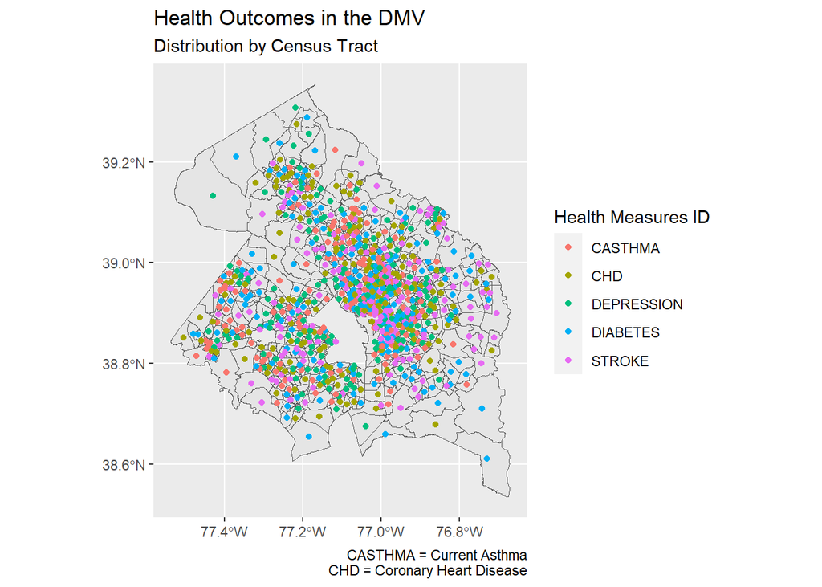

```r
# Change geometry to be readable by SF

Health_map <- Health %>%
  st_as_sf(wkt = "Geolocation", remove = FALSE) %>%
  st_set_crs(value = 4326) # setting CRS


# Map health outcomes
Health_map %>%
  ggplot() +
  geom_sf(data = DMV_tracts) +
  geom_sf(aes(color = MeasureId)) +
  labs(
    title = "Health Outcomes in the DMV",
    subtitle = "Distribution by Census Tract",
    caption = "CASTHMA = Current Asthma\nCHD = Coronary Heart Disease",
    color = "Health Measures ID"
  )
```

This map demonstrates that at least one of the health outcomes we selected are present in each census tract in our dataset. Later in the project, we will dive further into the connection between location and health outcomes, and use economic data to further understand how health outcomes differ in each census tract. There isn’t an obvious pattern among the tracts that show a concentration of specific health outcomes by specific area.

### Debt-to-Income Ratio Data

The debt-to-income ratio dataset comes from the Federal Housing Finance Agency, which records data about home purchase loans. This dataset has information on individual loans taken out for single-family homes, along with specifications of census tracts. The data also include the debt-to-income ratio of each borrower, which is an indication of how much debt the borrower has taken on in relation to their income. The debt-to-income ratio (or DTI) is generally regarded as a reliable indicator of a borrower’s financial health, or ability to pay monthly debt payments. Other useful variables in this dataset that will be used in our analysis are census tract indicators, the percentage of minorities in a given census tract, tract median income, and mortgage amount.

We chose to download the dataset from 2021, as this will reflect the same year as our CDC health outcomes dataset. To download the correct dataset for our analysis, go to this [link:](https://www.bcbs.com/the-health-of-america/articles/healthy-communities-mean-better-economy) and download the ZIP file for the 2021 Freddie Mac dataset. Alternatively, you can use the txt file we included with our submission titled “debt_to_income.txt”

```r
# loading debt to income ratio data

debt_to_income <- read.table("debt_to_income.txt", header = FALSE)
# Have to manually name columns

colnames(debt_to_income) <- c('enterprise', 'record_num','state_postal_code', 'MSA', 'COUNTYFP', 'NAME10', 'percent_minority', 'median_income', 'MSA_median_income', 'tract_income_ratio', 'borrower_income','AMI', 'borrower_income_ratio', 'UPB','purpose_of_loan', 'fed_guarantee', 'num_borrowers', 'first_time_borrower', 'borrower_race_1', 'race_2', 'race_3', 'race_4', 'race_5', 'borrower_ethnicity', 'co_borrower_race_1', 'co_race_2', 'co_race_3', 'co_race_4', 'co_race_5',   'co_borrower_ethnicity', 'borrower_gender', 'co_borrower_gender', 'borrower_age', 'co_borrower_age', 'occupancy_code', 'rate_spread', 'HOEPA_status', 'property_type', 'lien_status', 'borrower_over_sixtytwo', 'co_borrower_over_sixtytwo', 'LTV_ratio', 'note_date', 'mortgage_term', 'num_units', 'interest_rate', 'note_amount', 'preapproval', 'application_channel', 'AUS_name', 'borrower_credscore_model', 'co_borrower_credscore_model', 'DTI_ratio', 'discount_points', 'rate_period', 'manufactured_home_ownership', 'property_value', 'rural_tract', 'lower_MS_delta', 'Mid_Appalachia', 'persistent_poverty_county', 'concentrated_poverty', 'high_opportunity_area', 'QOZ')

counties <- c(1, 59, 31, 33) # Name county vector to filter dataset to needed counties only

debt_to_income <- debt_to_income %>%
  filter(MSA == 47900)

debt_to_income <- debt_to_income %>%
  filter(COUNTYFP == counties) # Filtering to needed counties

# Mutate dataset to match county names of TIGRIS shapefile
debt_to_income <- debt_to_income %>%
  mutate(COUNTYFP =
    if_else(COUNTYFP == 1, "001", as.character(COUNTYFP)))

debt_to_income <- debt_to_income %>%
  mutate(COUNTYFP =
           if_else(COUNTYFP == 59, "059", as.character(COUNTYFP)))

debt_to_income <- debt_to_income %>%
  mutate(COUNTYFP =
           if_else(COUNTYFP == 31, "031", as.character(COUNTYFP)))

debt_to_income <- debt_to_income %>%
  mutate(COUNTYFP =
           if_else(COUNTYFP == 33, "033", as.character(COUNTYFP)))

debt_to_income$NAME10 <- as.numeric(debt_to_income$NAME10)

DMV_tracts$NAME10 <- as.numeric(DMV_tracts$NAME10)

debt_to_income$NAME10 <- debt_to_income$NAME10 / 100

#Merging the datasets by census tract name
debt_tract_2 <- full_join(DMV_tracts, debt_to_income, by = "NAME10")

# Setting CRS for geospatial visualizations

debt_tract_2 <- debt_tract_2 %>%
  st_as_sf(coords = c("INTPTLON10", "INTPTLAT10"), remove = FALSE) %>%
  st_set_crs(value = 4326) # setting CRS

#suppress progress bar
options(sf_progress = FALSE)

debt_tract_2 <- st_transform(debt_tract_2, crs = 4326)
```

The debt-to-income ratio dataset did not come with column names, so we used the data documentation to manually input the names. Some of the column names were changed to match the tigris shapefiles which will be used in later mergers.

### Exploratory Data Analysis using the debt-to-income ratio dataset

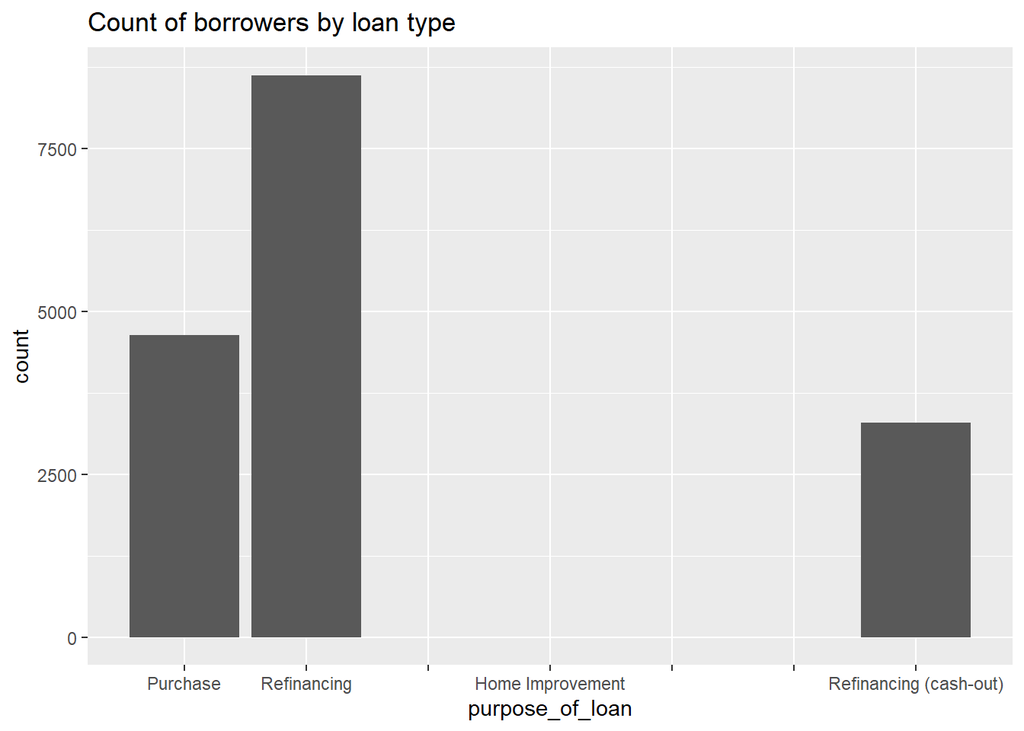

```r
# Exploratory data analysis to better understand the data
debt_totals <- debt_to_income %>%
  summarise(n = n())

debt_to_income %>%
  filter(purpose_of_loan == 3 | 4 | 5 | 6) %>%
  ggplot() +
  geom_bar(mapping = aes(x = purpose_of_loan)) +
  scale_x_continuous(breaks = c(1, 2, 3, 4, 5, 6, 7), minor_breaks = NULL, labels = c("Purchase", "Refinancing", " ", "Home Improvement", " ", " ", "Refinancing (cash-out)")) +
  ggtitle("Count of borrowers by loan type")
```

Here we can see that most of the loans taken out are for the purposes of refinancing a mortgage, while a smaller number are for initial purchase of homes.

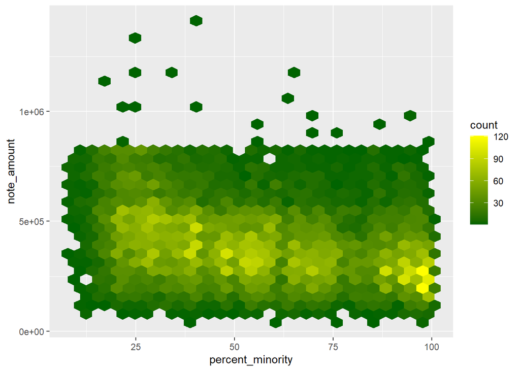

```r
debt_to_income %>%
  ggplot() +
  geom_hex(mapping = aes(x = percent_minority, y = note_amount)) +
    scale_fill_continuous(low = "darkgreen", high = "yellow") +
  scale_y_continuous()
```

### Banks

This dataset provides the exact locations of banks in the District of Columbia. The data is available for access on [Washington DC’s open data portal](https://opendata.dc.gov/datasets/DCGIS::bank-locations/explore?location=39.007423%2C-76.009578%2C8.59). The locations of the banks are provided by the Department of Insurance Securities and Banking (DISB). The dataset is updated irregularly, as needed, and provides the latitude and longitude coordinates of the banks across DC.

```r
#loading banks data
banks <- read.csv("banks.csv")

# replace the white space with underscores and lower-case all of the letters in column names
names(banks) <- names(banks) %>%
  str_replace_all("\\s", "_") %>%
  str_to_lower()
```

Replacing white space in the dataframe will help to make the dataset more readable with R programs.

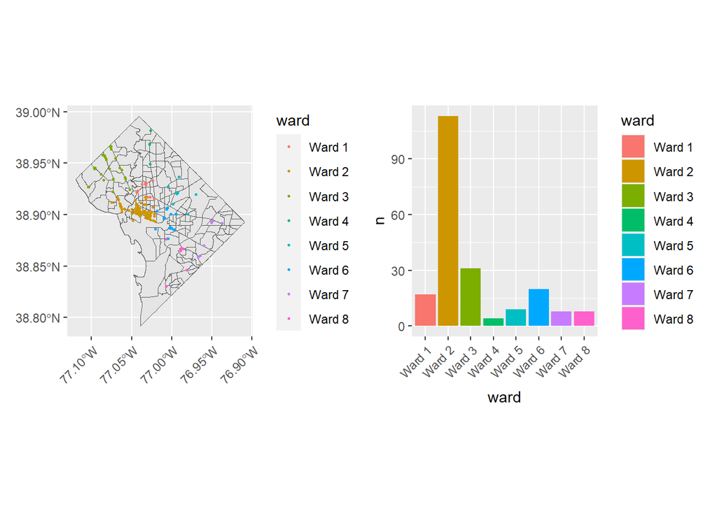

```r
#filter the data to rows about banks that have valid longitudes and latitudes
banks_locations <- banks %>%
  filter(!is.na(longitude), !is.na(latitude))

#convert longitude and latitude columns into spatial geometries
banks_locations <- st_as_sf(banks_locations, coords = c("longitude", "latitude"))

#set CRS to 4326 (WGS 84)
banks_locations <- st_set_crs(banks_locations, value = 4326)

#plot map using ggplot2
banks_locations_1 <- banks_locations %>%
ggplot()+
  geom_sf(data = DC_tracts) +
  geom_sf(data = banks_locations, aes(color = ward), size = 0.6) +
  theme(axis.text.x = element_text(angle = 45, hjust = 1))

banks_locations_2 <- banks_locations %>%
  group_by(ward) %>%
  summarize(n = n()) %>%
  ggplot() +
  geom_col(aes(x= ward, y = n, fill = ward)) +
  theme(axis.text.x = element_text(angle = 45, hjust = 1))

banks_locations_1 + banks_locations_2
```

We can see by this map of the locations of the banks in DC in each census tract that the highest concentration of banks is in Ward 2. This is understandable since the city center is located within Ward 2. This map illustrates the low density of banks in Wards 7, 8 and 4 as compared to the rest of DC, which is also confirmed in the bar graph showing the count of banks in each ward. Wards 7 and 8 have the highest concentration of people in poverty in DC, while Ward 4 is mostly a residential region where the population is majority non-white. This map gives a preview of our future analysis that proximity to banks is demonstrative of economic outcomes in areas. Since access to banking is indicative of one’s access to resources, this map shows the relationship between resources and economic outcomes, specifically for high-poverty areas like Ward 7 and 8, where there are high concentrations of people in poverty and low access to banks.

```r
# spatial join and census tracts
#match CRS of both objects using the given CRS: 4326
banks_chloro <- st_transform(banks_locations, crs = st_crs(DMV_tracts))

#spatial join bank points and census tracts
banks_join <- st_join(DMV_tracts, banks_chloro, st_intersects)

banks_merged_1 <- banks_join %>%
  group_by(GEOID10) %>%
  summarize(
    bank_count = sum(!is.na(name), na.rm = TRUE))

#join census tract back to new dataframe
banks_merged_1 <- st_join(DMV_tracts, banks_merged_1, join = st_intersects)
```

## Part 03

## Geospatial Analysis with Banks

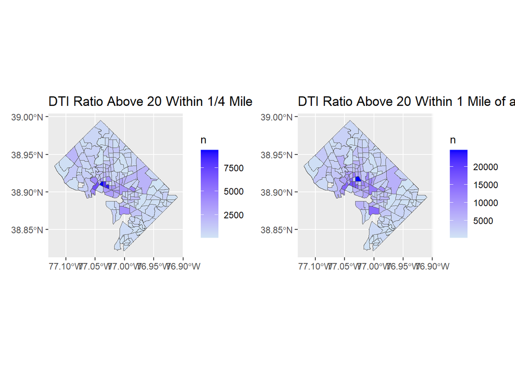

```r
# looking at economic outcomes in relationship to distance to banks
banking<- st_transform(banks_join, crs = 4326)
DC<- st_transform(DC_tracts, crs = 4326)

econ <- debt_tract_2 %>%
  filter(COUNTYFP10 == "001") %>%
  st_as_sf(coords = c("INTPTLON10", "INTPTLAT10"), remove = FALSE) %>%
  st_set_crs(value = 4326) # setting CRS

# close proximity to banks
banks_filtered<- st_join(banking, DC, left= FALSE)
banks_econ_1<- st_join(econ, st_buffer(banks_filtered, dist = 400))

max_banks_econ_1<- banks_econ_1 %>%
  group_by(NAME10) %>%
  filter(DTI_ratio > 20) %>%
  summarize(n = n())

Banks_Debt_400 <- max_banks_econ_1 %>%
  ggplot() +
  geom_sf(aes(fill = n)) +
   scale_fill_gradient(
    low = "#D1E3F5",
    high = "blue",
    na.value = "white"
  ) +
  labs(
    title = "DTI Ratio Above 20 Within 1/4 Mile of a Bank",
  )

# far proximity to banks

banks_econ_2<- st_join(econ, st_buffer(banks_filtered, dist = 1600))

max_banks_econ_2<- banks_econ_2 %>%
  group_by(NAME10) %>%
  filter(DTI_ratio > 20) %>%
  summarize(n = n())

Banks_Debt_1600 <- max_banks_econ_2 %>%
  ggplot() +
  geom_sf(aes(fill = n)) +
   scale_fill_gradient(
    low = "#D1E3F5",
    high = "blue",
    na.value = "white"
  ) + labs(
    title = "DTI Ratio Above 20 Within 1 Mile of a Bank",
  )

Banks_Debt_400 + Banks_Debt_1600
```

Within 1 mile of a bank, census tract 44.00 had the highest number of people with a debt to income ratio over 20, with about 24,684 people. Census tracts 53.01, 52.01, and 55.00 had the next highest numbers. Census tract 44.00 is the area near Howard University, on U Street. Census tract 53.01 is near Dupont Circle. Census tract 55.00 is the area near Foggy Bottom and GWU, while Census tract 52.01 is in Logan Circle. These census tracts are all densely populated and close to the city center as well as universities and restaurants. The fact that there are high concentrations of people with high debt to income ratios in these areas that are all within 1 mile of a bank affirms what we found in the previous map with proximity to banks set at a quarter of a mile. Single family homes are quite expensive and difficult to obtain in these areas, but there are also a wide variety of resources available in these areas. These census tracts are all also majority non-minority, which coincides with literature that points to majority Black neighborhoods having low access to banking and low access to housing loans.

```r
#looking at public health outcomes in relationship to distance to banks

banking<- st_transform(banks_join, crs = 4326)
DC<- st_transform(DC_tracts, crs = 4326)

st_transform(Health_map, crs = 4326)
```

```
Simple feature collection with 4330 features and 24 fields
Geometry type: POINT
Dimension:     XY
Bounding box:  xmin: -77.5045 ymin: 38.61075 xmax: -76.70545 ymax: 39.3072
Geodetic CRS:  WGS 84
# A tibble: 4,330 × 25
    Year StateAbbr StateDesc CountyName CountyFIPS LocationName DataSource
 * <dbl> <chr>     <chr>     <chr>           <dbl>        <dbl> <chr>
 1  2021 MD        Maryland  Montgomery      24031  24031700613 BRFSS
 2  2021 MD        Maryland  Montgomery      24031  24031700904 BRFSS
 3  2021 MD        Maryland  Montgomery      24031  24031700718 BRFSS
 4  2021 MD        Maryland  Montgomery      24031  24031700306 BRFSS
 5  2021 MD        Maryland  Montgomery      24031  24031701508 BRFSS
 6  2021 MD        Maryland  Montgomery      24031  24031701408 BRFSS
 7  2021 MD        Maryland  Montgomery      24031  24031701212 BRFSS
 8  2021 MD        Maryland  Montgomery      24031  24031700818 BRFSS
 9  2021 MD        Maryland  Montgomery      24031  24031700817 BRFSS
10  2021 MD        Maryland  Montgomery      24031  24031700500 BRFSS
# ℹ 4,320 more rows
# ℹ 18 more variables: Category <chr>, Measure <chr>, Data_Value_Unit <chr>,
#   Data_Value_Type <chr>, Data_Value <dbl>, Data_Value_Footnote_Symbol <lgl>,
#   Data_Value_Footnote <lgl>, Low_Confidence_Limit <dbl>,
#   High_Confidence_Limit <dbl>, TotalPopulation <dbl>, Geolocation <chr>,
#   LocationID <dbl>, CategoryID <chr>, MeasureId <chr>, DataValueTypeID <chr>,
#   Short_Question_Text <chr>, Counties <dbl>, geometry <POINT [°]>
```

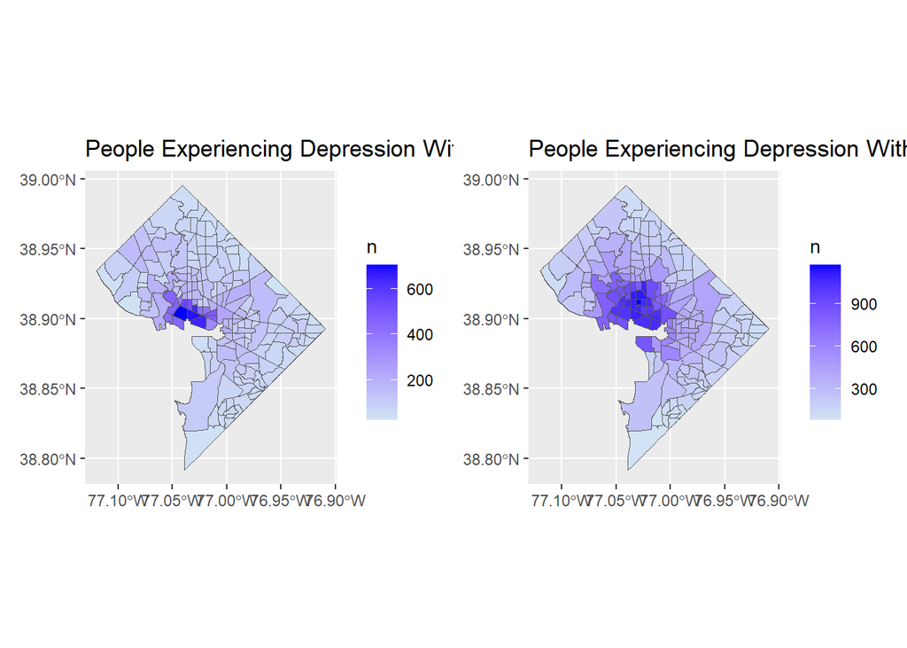

```r
Health_map <- st_transform(Health_map, crs = st_crs(DMV_tracts))
Health_map <- st_join(DMV_tracts, Health_map, st_intersects)


Health_DC <- Health_map %>%
  filter(COUNTYFP10 == "001") %>%
  filter(MeasureId == "DEPRESSION")


#transforming so it matches for the spatial join
banks_filtered<- st_join(banking, DC, left= FALSE)

banks_filtered <- st_transform(banks_filtered, crs = 4269)


# close proximity to banks

banks_health_1<- st_join(Health_DC, st_buffer(banks_filtered, dist = 400))

max_banks_health_1 <- banks_health_1 %>%
  group_by(NAME10) %>%
  summarize(n = n())


Banks_Depression_400 <- max_banks_health_1 %>%
  ggplot() +
  geom_sf(aes(fill = n)) +
   scale_fill_gradient(
    low = "#D1E3F5",
    high = "blue",
    na.value = "white"
  ) + labs(
    title = "People Experiencing Depression Within 1/4 Mile of a Bank",
  )


# far proximity to banks
banks_health_2<- st_join(Health_DC, st_buffer(banks_filtered, dist = 1600))

max_banks_health_2 <- banks_health_2 %>%
  group_by(NAME10) %>%
  summarize(n = n())


Banks_Depression_1600 <- max_banks_health_2 %>%
  ggplot() +
  geom_sf(aes(fill = n)) +
   scale_fill_gradient(
    low = "#D1E3F5",
    high = "blue",
    na.value = "white"
  )+ labs(
    title = "People Experiencing Depression Within 1 Mile of a Bank",
  )


Banks_Depression_400 + Banks_Depression_1600
```

## Visualization from the debt-to-income dataset

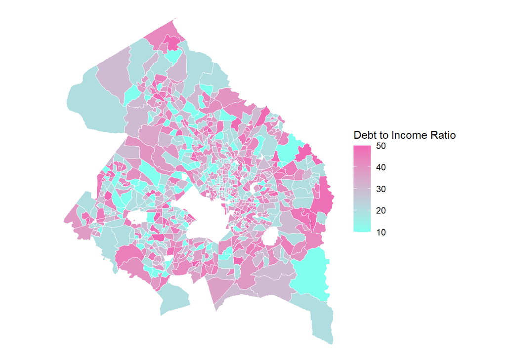

```r
# Debt-to-income ratio Choropleth
p3 <- debt_tract_2 %>%
  ggplot() +
  geom_sf(
    aes(
      fill = DTI_ratio), color = "White", size = 0.1) +
  scale_fill_gradient(
    low = "#81FFEF",
    high = "#F067B4",
    na.value = "white"
  ) +
  labs(
    fill = "Debt to Income Ratio"
  ) +
  theme_void()

p3
```

## Visualizations of health outcomes in the DMV area

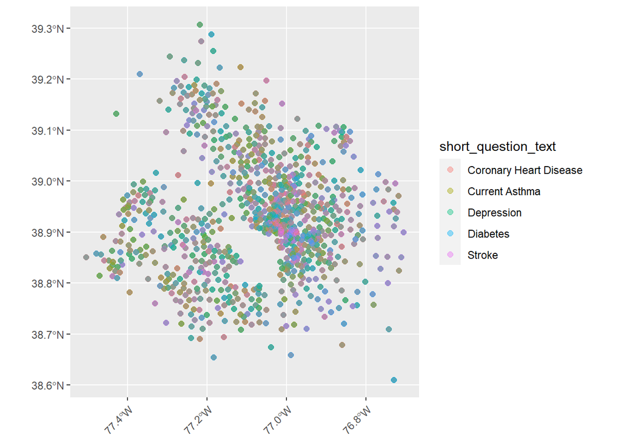

```r
#Merged CDC Places dataset with census tracts and made graph and choropleths

#Read in CSV of CDC data
Health1 <- read_csv("PLACES.csv")

#Clean data and get long and lat columns
Health2 <- Health1 %>%
  separate(col = Geolocation, into = c("point", "coordinates"), sep = " ", extra = "merge", remove = FALSE) %>%
  separate(col = coordinates, into = c("longitude", "latitude"), sep = " ", remove = TRUE)

Health2 <- Health2 %>%
  mutate(longitude = gsub("[()]", "", longitude),
         latitude = gsub("[()]", "", latitude))

names(Health2) <- names(Health2) %>%
  str_to_lower()

#Use consistent health measures: CASTHMA, CHD, Depression, Diabetes, Stroke

Health3 <- Health2 %>%
  filter(measureid %in% c("CASTHMA", "CHD", "DIABETES", "STROKE", "DEPRESSION") &
           complete.cases(longitude, latitude))

#convert longitude and latitude columns into spatial geometries
sf_Health <- st_as_sf(Health3, coords = c("longitude", "latitude"))
#set CRS to 4326 (WGS 84)
sf_Health <- st_set_crs(sf_Health, value = 4326)

#plot map using ggplot2
sf_Health |>
  ggplot() +
  geom_sf(
    aes(color = short_question_text), alpha = 0.4, size = 2) +
  theme(axis.text.x = element_text(angle = 45, hjust = 1))
```

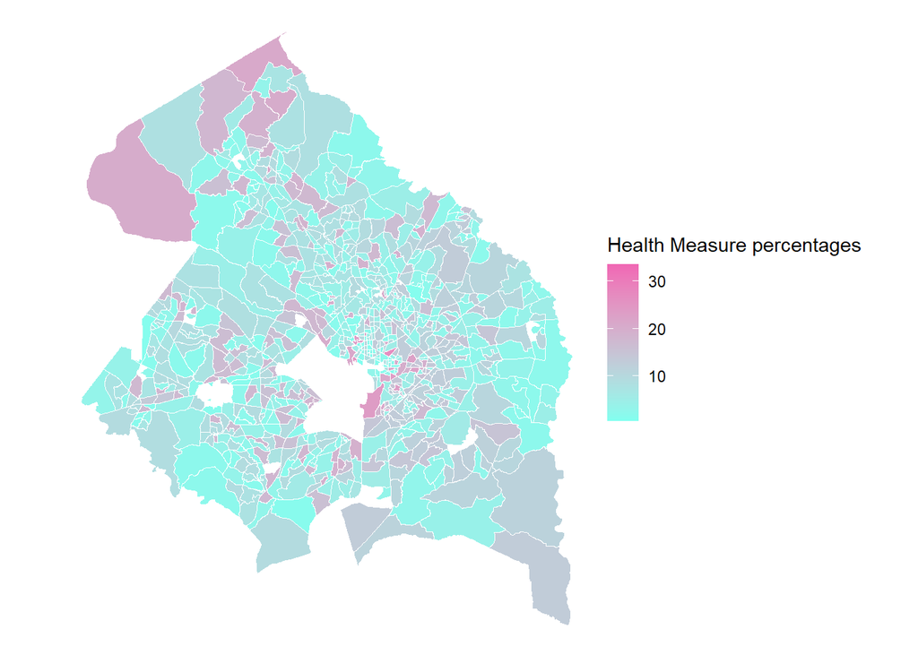

```r
#Perform a Spatial Join and Create Choropleth

#match cRS
sf_Health2 <- st_transform(sf_Health, crs = st_crs(DMV_tracts))

#spatial_join health points and census tracts
Health_join <- st_join(sf_Health2, DMV_tracts, st_intersects)

#calculate the count of health measures in new dataframe
health_merged <- Health_join |>
  group_by(NAME10, data_value)

#join census tract back to new dataframe
health_merged2 <- st_join(DMV_tracts, health_merged, join = st_intersects)

#create choropleth maps

p4 <- health_merged2 %>%
  ggplot() +
  geom_sf(
    aes(
      fill = data_value), color = "white", size = 0.1) +
  scale_fill_gradient(
    low = "#81FFEF",
    high = "#F067B4",
    na.value = "white"
  ) +
  labs(
    fill = "Health Measure percentages") +
  theme_void()

p4
```

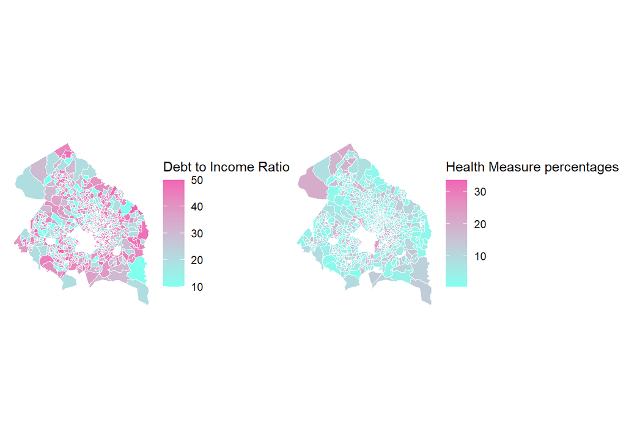

```r
combined_plot <- p3 + p4

combined_plot
```

This side by side comparison shows somewhat of a trend that tracts with lower DTI ratios have a higher percentage of health conditions. This may be because tracts where a majority of people are not able to leverage more debt against their income are worse off in terms of their health. This goes against our initial hypothesis that tracts with higher debt to income ratios would also experience higher rates of health conditions.

#### Merging Health and Debt-to-Income Dataset

```r
#Merging health dataset with debt_tract_2

#Converting long and lat coordinates to sf objects
debt_tract_2_sf <- st_as_sf(debt_tract_2, coords = c("INTPTLON10", "INTPTLAT10"), crs = 4326)

# Convert 'Geolocation' column to an sf object
Health_sf <- st_as_sf(Health, wkt = "Geolocation", crs = 4326)

#Confirm if health and debt use the same coordinate reference systems (crs)

#Transform debt dataset to match health
debt_tract_2_sf <- st_transform(debt_tract_2_sf, st_crs(Health_sf))

#Spatial Join
health_debt <- st_join(debt_tract_2_sf, Health_sf, join = st_intersects)
```